# Hypothesis Testing

## 3.3) P and Power

**Now plot power for an alpha of 0.05, but use color for different SD values. Include our threshold power of 0.8.**

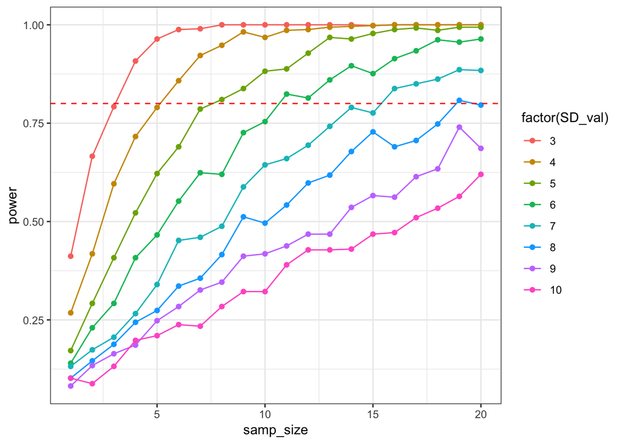

```r
my_plot_data <- my_data %>%
  #for each sample size and Standard Deviation
  group_by(samp_size, SD_val) %>%
  #calculate type 2 error rate for an alpha of 0.05
  summarise(error_rate = sum(p > 0.05)/n()) %>%
  ungroup() %>%
  #calculate power
  mutate(power = 1 - error_rate)

#Plot power with threshold of 0.8
ggplot(data = my_plot_data, mapping = aes(x = samp_size,
        y = power, group = SD_val, color = factor(SD_val))) +
        geom_line() +
        geom_point() +
        geom_hline(yintercept = 0.8, color = "red",
                   lty = 2) +
        theme_bw()
```

## 3.4) Many Alphas

#### Last, use crossing again to explore changing alphas from 0.01 to 0.1. Plot power curves with different alphas as different colors, and use faceting to look at different SDs.

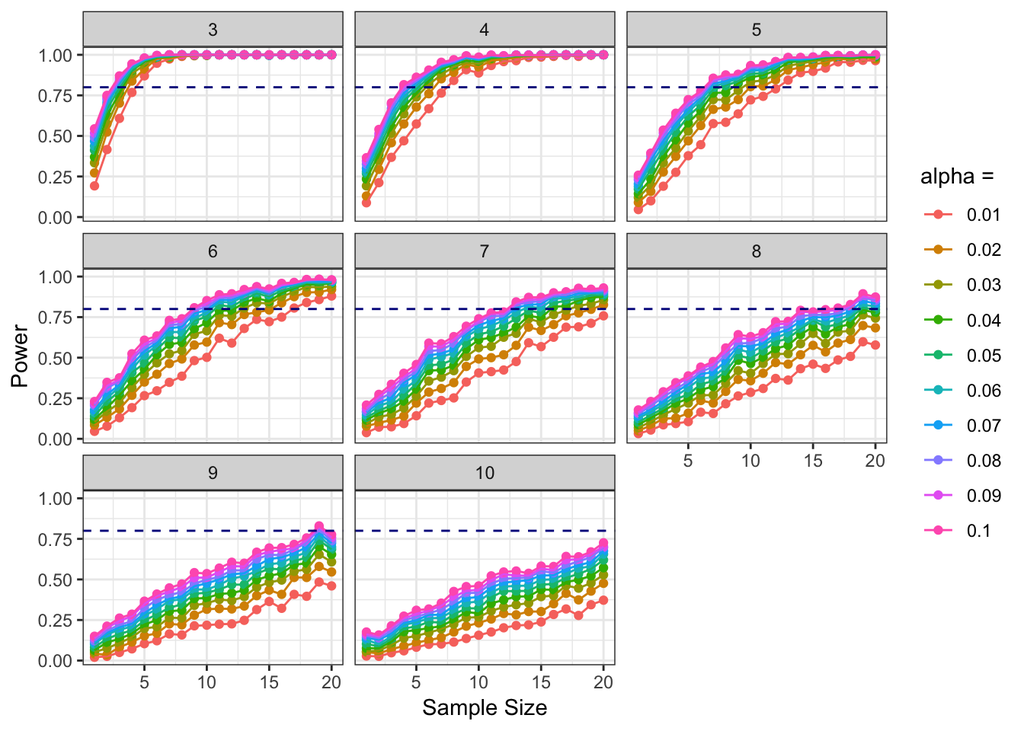

```r
#Establish multiple alphas
alpha <- seq(0.01, 0.1, .01)
my_alpha_data <- my_data %>%
  #add to my data
  crossing(alpha = alpha) %>%
  group_by(samp_size, alpha, SD_val) %>%
  #calculate type 2 error rate
  summarise(error_rate = sum(p > alpha)/n()) %>%
  ungroup() %>%
  #specify power
  mutate(power = 1 - error_rate)

#plot
ggplot(data = my_alpha_data,
       mapping = aes(x = samp_size, y = power, color = factor(alpha), group = alpha)) +
  geom_point() +
  geom_line() +
  facet_wrap (~SD_val) +
  geom_hline(yintercept = 0.8, color = "darkblue",
             lty = 2) +
  labs(x = "Sample Size", y = "Power", color = "alpha = ")+
  theme_bw()
```

#### 3.6) How do you think that changing the effect size would affect power?

Changing the effect size also changes the power of our statsitical test. However, it is important to note that if effect sized is increased too much we risk Type I Error. It is important to make sure effect size reflects the realities of your population.